# displayERUM

dan carver

01 December, 2020

## Visaulize the projections

### Can 1

Can 1=-9.79818 + mat (0.3032) + TD (0.25038) + map (0.00327) + msp (-0.00337) + ahm (-0.01356) + PAS (-0.00264) + emt (-0.05372)

R2= 0.85

Can 1  
Observed data mapping intervals at .01 CI - 1 -2.2464 -1.9807

- 2 -1.9807 -1.7150
- 3 -1.7150 -1.4493
- 4 -1.4493 -1.1836
- 5 -1.1836 -0.9179
- 6 -0.9179 -0.6522
- 7 -0.6522 -0.3865
- 8 -0.3865 -0.1208
- 9 -0.1208 0.1449
- 10 0.1449 0.4106
- 11 0.4106 0.6763
- 12 0.6763 0.9420
- 13 0.9420 1.2077
- 14 1.2077 1.4734
- 15 1.4734 1.7391

### Can 2

Can 2 = -25.8418 + mat (-1.7214) + mcmt (0.50829) + map (0.00156) + ahm (0.02009) + nffd (0.05013) + emt (-0.11856) + ext (0.65382)

R2 = 0.81

Can2  
Observed data mapping intervals at .01 CI - 1 -3.1078 -2.8073

- 2 -2.8073 -2.5068
- 3 -2.5068 -2.2063
- 4 -2.2063 -1.9058
- 5 -1.9058 -1.6053
- 6 -1.6053 -1.3048
- 7 -1.3048 -1.0043
- 8 -1.0043 -0.7038
- 9 -0.7038 -0.4033
- 10 -0.4033 -0.1028
- 11 -0.1028 0.1977
- 12 0.1977 0.4982
- 13 0.4982 0.7987
- 14 0.7987 1.0992
- 15 1.0992 1.3997

### Shoot Weight

Shoot wt. = -69.2096 + mat (38.72942) + mcmt (-46.7416) + map (0.31101) + pas (-0.37035) + emt (10.9494)

R2 = 0.59

Shoot wt.  
Observed data mapping intervals at .01 CI

- 1 0 39.4
- 2 39.4 78.8
- 3 78.8 118.2
- 4 118.2 157.6
- 5 157.6 197
- 6 197 236.4
- 7 236.4 275.8
- 8 275.8 315.2
- 9 315.2 354.6

### Bloom Day

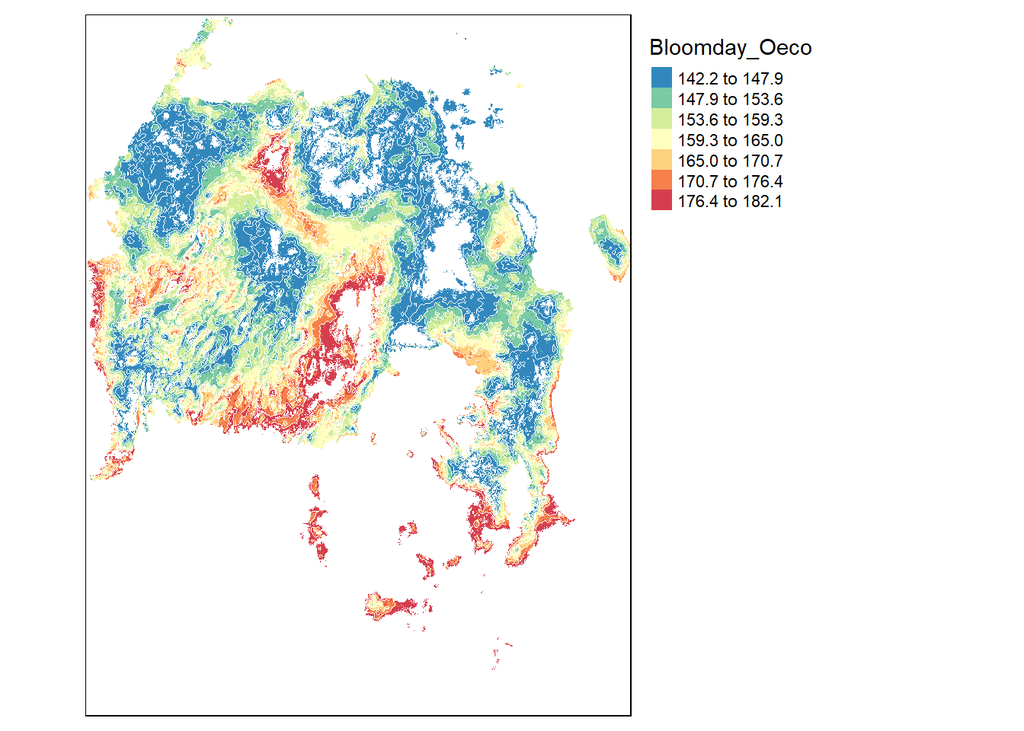

Bloom day

Bloom day = 400.9691 + mat (28.63729) + mcmt (-14.2239) + ahm (-0.37372) + nffd (-0.48261) + emt (2.59468) + ext (-7.94837)

R2 = 0.75

Bloom day  
Observed data mapping intervals at .01 CI

- 1 136.5 142.2
- 2 142.2 147.9
- 3 147.9 153.6
- 4 153.6 159.3
- 5 159.3 165
- 6 165 170.7
- 7 170.7 176.4
- 8 176.4 182.1

### Umbel Width

Umbel width = 26.46658 + mat (5.26435) + mwmt (-12.1966) + mcmt (9.09411) + td (11.323) + ahm (-0.07219) + ext (-1.09539)

R2 = 0.62

Umbel width Observed mapping intervals at .01 CI

- 1 2.6 4.32
- 2 4.3 6.02
- 3 6 7.72
- 4 7.7 9.42
- 5 9.4 11.12
- 6 11.1 12.82
- 7 12.8 14.52
- 8 14.5 16.22
- 9 16.2 17.92
- 10 17.9 19.62
- 11 19.6 21.32
- 12 21.3 23.02